# Coursework 1

School of Mathematical Sciences

Masturina Mohd Zainudin

March 2024

### 1.0 Prophet - What is it about?

Meta, formerly known as Facebook, developed Prophet. It’s not a product you directly interact with, but rather a software tool used for time series forecasting.

**Prophet’s functionalities that offer valuable advantages for time series analysis:**

*Makes predictions about future trends:*

- It analyses historical data to identify patterns and seasonality
- Then forecast what might happen next
- Helpful for businesses that need to predict things like sales, website traffic or resource allocation.

*Works well with specific data:*

- Prophet is designed for time series data, which means data points are collected at regular intervals over time.
- Good at handling data that has trends and seasonal patterns.
- Example: daily sales figures or website visits that spike around holidays.

*Relatively easy to use:*

- User friendly - library available to use in RStudio & Python

### 1.1 Getting started - install packages

- Install by typing `install.packages("prophet")` at console when install it for the first time.
- Meta suggests using the latest release. Then also install: i. first run `install.packages("remotes")` and then ii. run `remotes::install_github('facebook/prophet@*release', subdir='R')`

### 1.2 What is CO2?

Mauna Loa Atmospheric CO2 Concentration Atmospheric concentrations of CO_2 are expressed in parts per million (ppm) and reported in the preliminary 1997 SIO manometric mole fraction scale.

Format: A time series of 468 observations; monthly from 1959 to 1997.

Details: The values for February, March and April of 1964 were missing and have been obtained by interpolating linearly between the values for January and May of 1964.

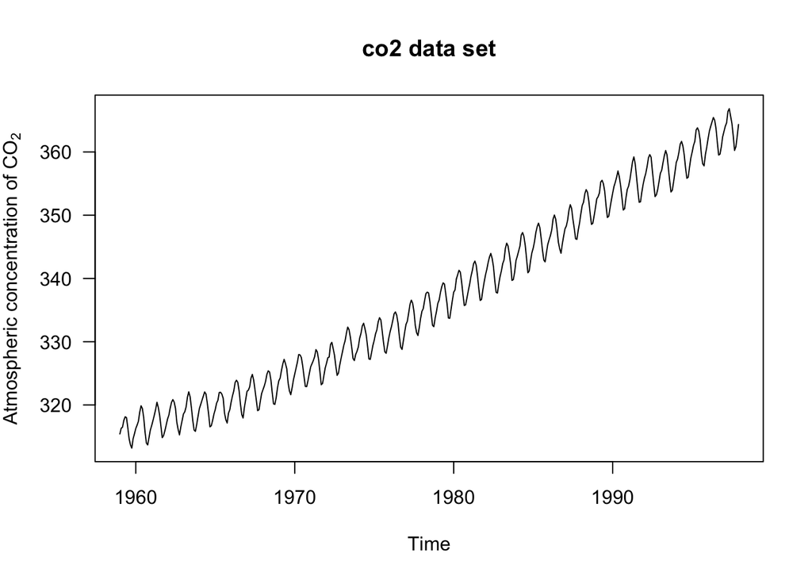

```r
require(graphics)
plot(co2, ylab = expression("Atmospheric concentration of CO"[2]),
     las = 1)
title(main = "co2 data set")
```

Overview of CO_2 Dataset

```r
str(co2)
```

```
##  Time-Series [1:468] from 1959 to 1998: 315 316 316 318 318 ...
```

```r
head(co2)
```

```
## [1] 315.42 316.31 316.50 317.56 318.13 318.00
```

```r
summary(co2)
```

```
##    Min. 1st Qu.  Median    Mean 3rd Qu.    Max.
##   313.2   323.5   335.2   337.1   350.3   366.8
```

### 1.3 Purpose of the project

**The purpose of this project is to analyse and forecast CO2 concentration levels over time. It utilises the concept of time series analysis.**

Time series analysis involves techniques for:

- *Understanding trends:*

Identifying the overall direction or pattern in which the data is moving over time (e.g., increasing, decreasing, or staying relatively constant).

- *Identifying seasonality:*

Detecting recurring patterns within the data that occur at specific time intervals (e.g., seasonal variations in CO2 levels).

- *Forecasting future values:*

Leveraging past data to make informed predictions about future values in the time series (e.g., predicting CO2 concentrations for the upcoming quarters).

### 2.0 Prophet Model for CO2 Forecasting

#### Run required library

```r
library(prophet)
library(remotes)
require(graphics)

dataframe <- read.csv('https://raw.githubusercontent.com/facebook/prophet/main/examples/example_wp_log_peyton_manning.csv')
```

#### Create a data frame for CO2 data

Creates a dataframe co2.df with dates represented in year and month format (ds) extracted from the co2 object and CO2 concentration values (y) assigned to the dataframe.

```r
co2.df = data.frame(ds = zoo::as.yearmon(time(co2)), y = co2)

#check head, tail of dataframe
head(co2.df)
```

```
##         ds      y
## 1 Jan 1959 315.42
## 2 Feb 1959 316.31
## 3 Mar 1959 316.50
## 4 Apr 1959 317.56
## 5 May 1959 318.13
## 6 Jun 1959 318.00
```

```r
tail(co2.df)
```

```
##           ds      y
## 463 Jul 1997 364.52
## 464 Aug 1997 362.57
## 465 Sep 1997 360.24
## 466 Oct 1997 360.83
## 467 Nov 1997 362.49
## 468 Dec 1997 364.34
```

#### Fit a Prophet model to the CO2 data

```r
co2_prophet_model = prophet::prophet(co2.df)
```

```
## Disabling weekly seasonality. Run prophet with weekly.seasonality=TRUE to override this.
```

```
## Disabling daily seasonality. Run prophet with daily.seasonality=TRUE to override this.
```

#### Generate future timestamps for forecasting

Creates a dataframe (“future”) containing future timestamps for forecasting based on the fitted Prophet model (co2_prophet_model).

The timestamps are spaced at quarterly intervals, and the function generates timestamps for 8 future periods.

These future timestamps will be used to make predictions using the Prophet model.

```r
future = prophet::make_future_dataframe(co2_prophet_model, periods = 8, freq = "quarter")

#check head & tail of future timestamps
head(future)
```

```
##           ds
## 1 1959-01-01
## 2 1959-02-01
## 3 1959-03-01
## 4 1959-04-01
## 5 1959-05-01
## 6 1959-06-01
```

```r
tail(future)
```

```
##             ds
## 471 1998-09-01
## 472 1998-12-01
## 473 1999-03-01
## 474 1999-06-01
## 475 1999-09-01
## 476 1999-12-01
```

#### Predict CO2 concentrations for future dates

```r
co2_forecast = predict(co2_prophet_model, future)

#check head & tail of co2_forecast
head(co2_forecast)
```

```
##           ds    trend additive_terms additive_terms_lower additive_terms_upper
## 1 1959-01-01 315.3634    -0.07727957          -0.07727957          -0.07727957
## 2 1959-02-01 315.4478     0.59480928           0.59480928           0.59480928
## 3 1959-03-01 315.5240     1.23422957           1.23422957           1.23422957
## 4 1959-04-01 315.6084     2.46165430           2.46165430           2.46165430
## 5 1959-05-01 315.6901     3.02106711           3.02106711           3.02106711
## 6 1959-06-01 315.7745     2.35171630           2.35171630           2.35171630
##        yearly yearly_lower yearly_upper multiplicative_terms
## 1 -0.07727957  -0.07727957  -0.07727957                    0
## 2  0.59480928   0.59480928   0.59480928                    0
## 3  1.23422957   1.23422957   1.23422957                    0
## 4  2.46165430   2.46165430   2.46165430                    0
## 5  3.02106711   3.02106711   3.02106711                    0
## 6  2.35171630   2.35171630   2.35171630                    0
##   multiplicative_terms_lower multiplicative_terms_upper yhat_lower yhat_upper
## 1                          0                          0   314.8015   315.7829
## 2                          0                          0   315.5726   316.5104
## 3                          0                          0   316.2802   317.2461
## 4                          0                          0   317.6018   318.5580
## 5                          0                          0   318.2155   319.1861
## 6                          0                          0   317.7035   318.6120
##   trend_lower trend_upper     yhat
## 1    315.3634    315.3634 315.2861
## 2    315.4478    315.4478 316.0426
## 3    315.5240    315.5240 316.7582
## 4    315.6084    315.6084 318.0701
## 5    315.6901    315.6901 318.7112
## 6    315.7745    315.7745 318.1262
```

```r
tail(co2_forecast)
```

```
##             ds    trend additive_terms additive_terms_lower
## 471 1998-09-01 365.3428      -3.086257            -3.086257
## 472 1998-12-01 365.6953      -0.974099            -0.974099
## 473 1999-03-01 366.0440       1.234230             1.234230
## 474 1999-06-01 366.4004       2.351716             2.351716
## 475 1999-09-01 366.7568      -3.055132            -3.055132
## 476 1999-12-01 367.1094      -0.975874            -0.975874
##     additive_terms_upper    yearly yearly_lower yearly_upper
## 471            -3.086257 -3.086257    -3.086257    -3.086257
## 472            -0.974099 -0.974099    -0.974099    -0.974099
## 473             1.234230  1.234230     1.234230     1.234230
## 474             2.351716  2.351716     2.351716     2.351716
## 475            -3.055132 -3.055132    -3.055132    -3.055132
## 476            -0.975874 -0.975874    -0.975874    -0.975874
##     multiplicative_terms multiplicative_terms_lower multiplicative_terms_upper
## 471                    0                          0                          0
## 472                    0                          0                          0
## 473                    0                          0                          0
## 474                    0                          0                          0
## 475                    0                          0                          0
## 476                    0                          0                          0
##     yhat_lower yhat_upper trend_lower trend_upper     yhat
## 471   361.7460   362.7723    365.2330    365.4366 362.2565
## 472   364.1868   365.2974    365.4872    365.8838 364.7212
## 473   366.6602   367.8608    365.7309    366.3281 367.2782
## 474   368.0589   369.4093    365.9522    366.8385 368.7521
## 475   362.9607   364.4533    366.1497    367.4093 363.7017
## 476   365.2291   367.0993    366.3447    367.9421 366.1335
```

#### Plot the original CO2 data and forecasted values

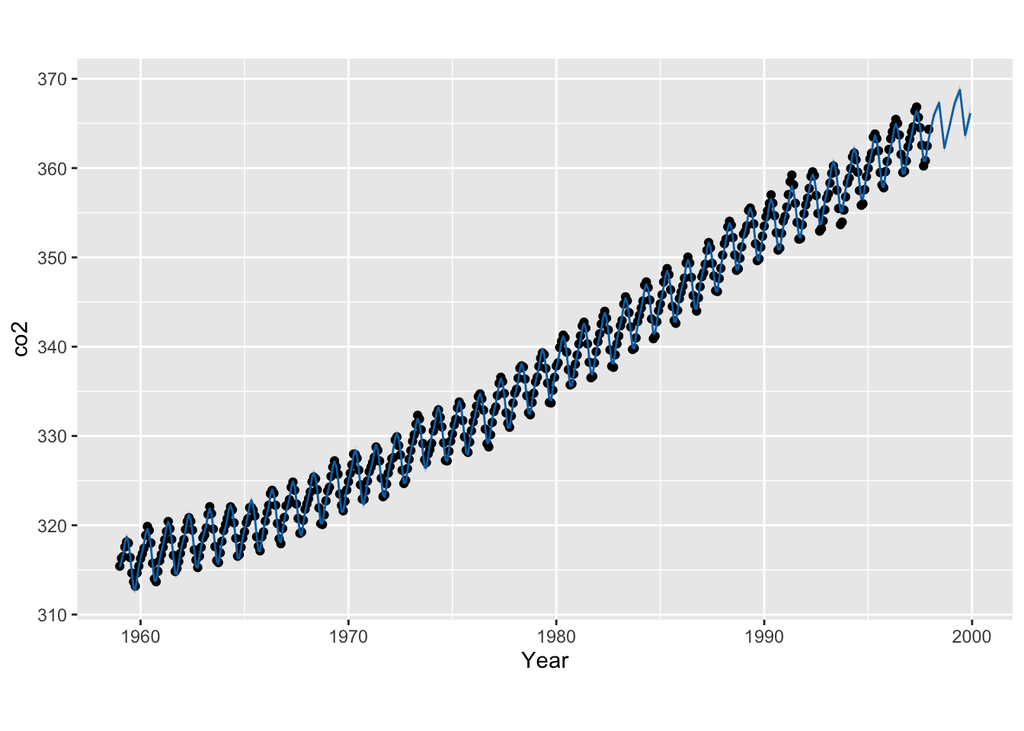

```r
plot(co2_prophet_model, co2_forecast, main = "co2 data & forecast", xlab = "Year", ylab = "co2")
```

### 2.1 Time Series Analysis

Using decompose funtion, where it will decompose a time series into seasonal, trend and irregular components using moving averages. Also deals with additive or multiplicative seasonal component.

```r
require(graphics)
decomposed <- decompose(co2)
decomposed$figure
```

```
##  [1] -0.05359649  0.61055921  1.37564693  2.51682018  3.00028509  2.32921053
##  [7]  0.81293860 -1.25052632 -3.05458333 -3.25194079 -2.06969298 -0.96512061
```

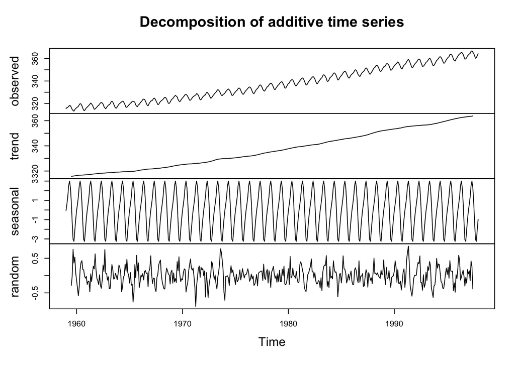

```r
plot(decomposed)
```

#### Trend

Trend represents the long-term movement or directionality of the time series data.

In the context of Prophet data, the trend component captures the overall *increasing* pattern over time

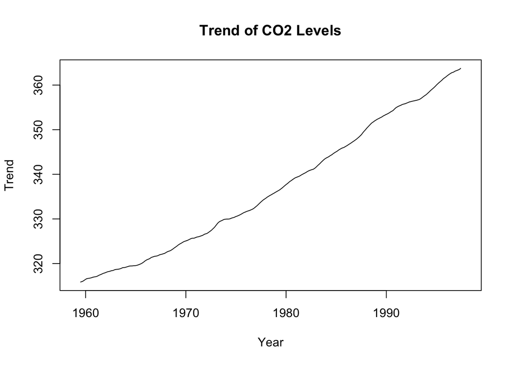

```r
decomposed <- decompose(co2)
plot(decomposed$trend, main = "Trend of CO2 Levels", xlab = "Year", ylab = "Trend")
```

#### Seasonal decomposition

Seasonality refers to the repetitive patterns or fluctuations that occur at regular intervals within the time series data.

In Prophet data, seasonality captures recurring patterns that repeat over fixed periods, such as daily, weekly, monthly, or yearly cycles.

For instance, if CO2 concentrations exhibit higher levels during certain months of the year due to seasonal factors, this would be captured in the seasonality component. For example, holidays like Christmas or New Year’s Day might affect CO2 concentrations due to changes in human activities.

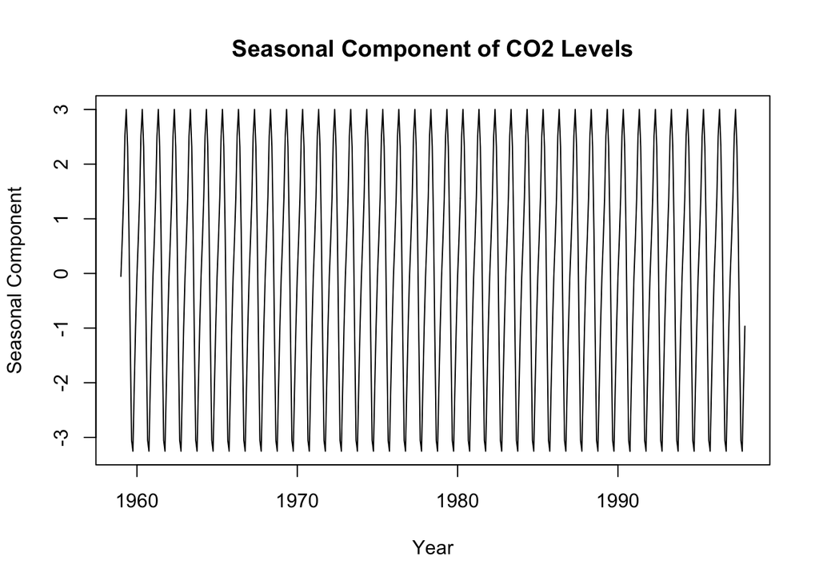

```r
decomposed <- decompose(co2)
plot(decomposed$seasonal, main = "Seasonal Component of CO2 Levels", xlab = "Year", ylab = "Seasonal Component")
```

#### Noise

Noise (Error Term): Represents the random fluctuations or unmodeled variability in the data.

There are slight random fluctuations of the data, especially on year 1970 and early 1990.

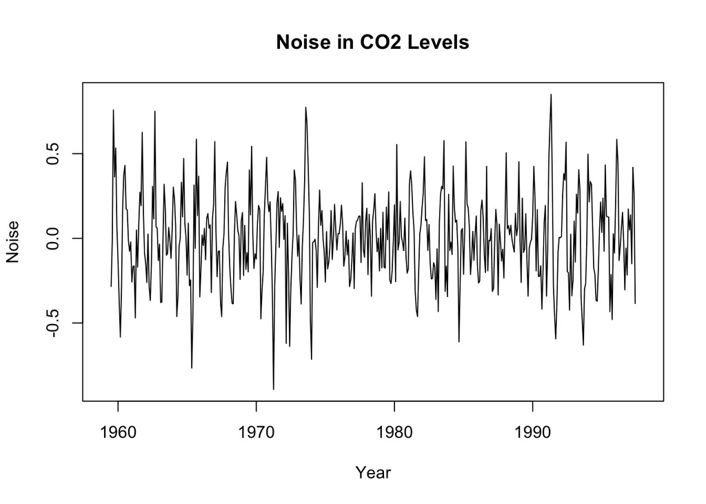

```r
noise <- co2 - decomposed$trend - decomposed$seasonal
plot(noise, main = "Noise in CO2 Levels", xlab = "Year", ylab = "Noise")
```

### 2.2 Linear Regression Model

Linar Regression Model to understand the underlying trends in the time series data and comparing it to the predictions made by the Prophet model.

Positive slope values indicate an increasing trend.

By fitting a linear regression model alongside the Prophet model, one can compare the linear trend estimated by the regression model with the trend component predicted by Prophet.

This comparison helps assess the linearity of the underlying trend and evaluate whether the Prophet model adequately captures the trend in the data.

```r
lm_model <- lm(y ~ ds, data = co2.df)

# Summary of the linear regression model
summary(lm_model)
```

```
##
## Call:
## lm(formula = y ~ ds, data = co2.df)
##
## Residuals:
##     Min      1Q  Median      3Q     Max
## -6.0399 -1.9476 -0.0017  1.9113  6.5149
##
## Coefficients:
##               Estimate Std. Error t value Pr(>|t|)
## (Intercept) -2.250e+03  2.127e+01  -105.8   <2e-16 ***
## ds           1.308e+00  1.075e-02   121.6   <2e-16 ***
## ---
## Signif. codes:  0 '***' 0.001 '**' 0.01 '*' 0.05 '.' 0.1 ' ' 1
##
## Residual standard error: 2.618 on 466 degrees of freedom
## Multiple R-squared:  0.9695, Adjusted R-squared:  0.9694
## F-statistic: 1.479e+04 on 1 and 466 DF,  p-value: < 2.2e-16
```

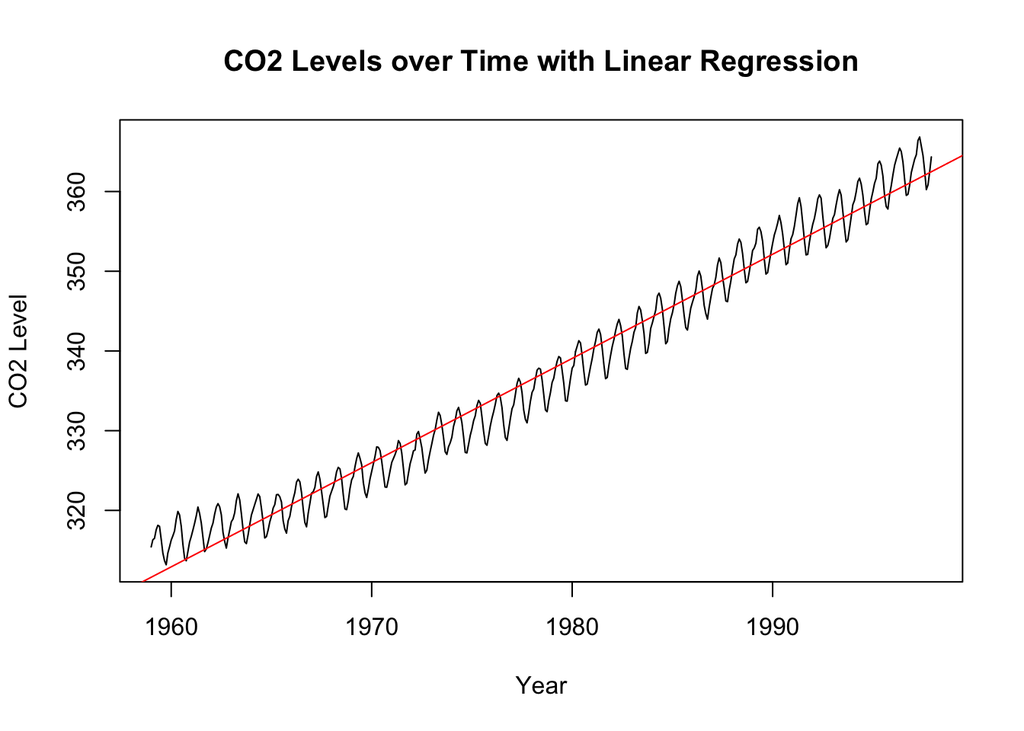

```r
# Plot the linear regression line
plot(co2.df$ds, co2.df$y, main = "CO2 Levels over Time with Linear Regression",
     xlab = "Year", ylab = "CO2 Level", type = "l")
abline(lm_model, col = "red")
```

### 2.3 Result

The primary result of the Prophet model is the forecasted values for CO2 concentrations for future time periods.

These forecasted values represent the model’s predictions of CO2 levels based on the observed trends, seasonality, noise and some other factors captured in the data.

In term of trend, it can be observed that CO2 level are generally increasing by year.

Seasonality in general refers to patterns that repeat over a fixed and known period, typically within a year or less. Patterns are often linked to natural or cultural events, such as holidays, weather patterns, or annual business cycles. Examples include higher CO2 emission during festive session. Seasonal patterns exhibit regular, predictable fluctuations with consistent shape and amplitude each year.

Noise in Prophet meta time series can affect the accuracy and reliability of the model’s predictions. Excessive noise may obscure underlying patterns and make it challenging to extract meaningful insights from the data. However, moderate levels of noise are expected in real-world data and are typically handled by the model through the estimation of prediction intervals. Handling Noise:

Techniques to reduce its impact must be explored, such as data preprocessing, outlier detection, or model refinement. Additionally, evaluating the prediction intervals provided by the model can help quantify the uncertainty associated with the forecasts and account for the presence of noise.

Understanding the presence of noise in Prophet Meta time series is essential for interpreting the model’s forecasts and making informed decisions based on the predicted values. It is important to recognise that noise is an inherent aspect of the data and to consider its implications when analysing and interpreting the results.

### 3.0 Exploring Prophet with new dataframe

Load Prophet library and insert new dataframe from [Prophet website](https://facebook.github.io/prophet/docs/quick_start.html#r-api)

```r
library(prophet)
df <- read.csv('https://raw.githubusercontent.com/facebook/prophet/main/examples/example_wp_log_peyton_manning.csv')
model <- prophet(df)
```

```
## Disabling daily seasonality. Run prophet with daily.seasonality=TRUE to override this.
```

```r
futures <- make_future_dataframe(model, periods = 365)


#check head and tail
head(futures)
```

```
##           ds
## 1 2007-12-10
## 2 2007-12-11
## 3 2007-12-12
## 4 2007-12-13
## 5 2007-12-14
## 6 2007-12-15
```

```r
tail(futures)
```

```
##              ds
## 3265 2017-01-14
## 3266 2017-01-15
## 3267 2017-01-16
## 3268 2017-01-17
## 3269 2017-01-18
## 3270 2017-01-19
```

```r
forecast <- predict(model, futures)
tail(forecast[c('ds', 'yhat', 'yhat_lower', 'yhat_upper')])
```

```
##              ds     yhat yhat_lower yhat_upper
## 3265 2017-01-14 7.823527   7.148732   8.551259
## 3266 2017-01-15 8.205303   7.482787   8.921762
## 3267 2017-01-16 8.530317   7.843999   9.247478
## 3268 2017-01-17 8.317719   7.587125   9.060272
## 3269 2017-01-18 8.150322   7.458673   8.890472
## 3270 2017-01-19 8.162248   7.434912   8.893053
```

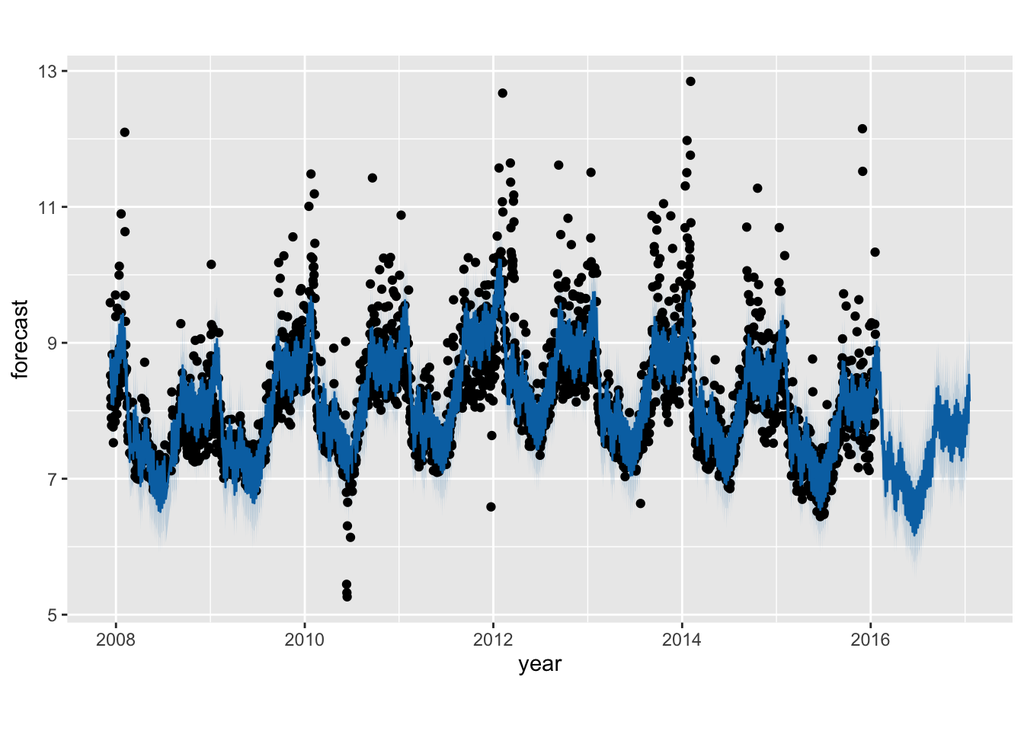

```r
plot(model, forecast, main = "Forecast", xlab="year", ylab="forecast")
```

Produce plot components of Prophet which contains trend with a forecasted data in period of 365 days, weekly plot which shows that highest value recorded is on Monday, and lowest is on Saturday. Also, yearly plot which shows that highest is around late January to early February, and lowest is around end of June.

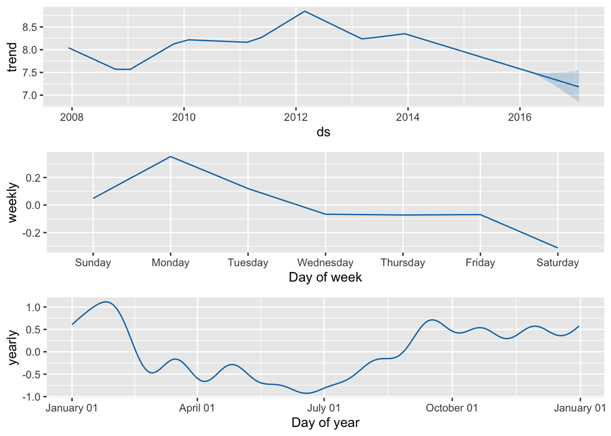

```r
prophet_plot_components(model, forecast)
```

Create an interactive plot of the forecast using dyplot command

```r
dyplot.prophet(model, forecast)
```

[interactive chart not shown]